# Kickstarter Projects Data

Tian Ren

### Introduction

Have you ever come up with some genius idea that could shake the world but never get launched because of the short of fund? Well, now you can use crowdfunding platform, but do you know which deadline can get you the highest backing rate? We will try to answer this question by walking through a complete data science project in this tutorial.

### Required Tools

You will need to install R and Rstudio for this project.

To install R in your computer go to https://cran.r-project.org/index.html and download and install the appropriate binary file.

To install Rstudio go to https://www.rstudio.com/products/rstudio/download/ and download the appropriate version of Rstudio.

Some R libraries are also needed:

- tidyverse

Finally, you will need the Kickstarter Projects Data, which can be obtained at https://www.kaggle.com/kemical/kickstarter-projects/data.

### 1. Data Processing

The data we acquired is a comma-separated value file (`.csv`). In order to use it in the project, we first need to read it into a varibale in R.

```r
# Read the data from file
kickstarter_table <- read_csv("ks-projects-201801.csv")
# Print first 6 rows of the data
head(kickstarter_table)
```

```
## # A tibble: 6 x 15
##        ID name           category  main_category currency deadline    goal
##     <int> <chr>          <chr>     <chr>         <chr>    <date>     <dbl>
## 1  1.00e⁹ The Songs of … Poetry    Publishing    GBP      2015-10-09  1000
## 2  1.00e⁹ Greeting From… Narrativ… Film & Video  USD      2017-11-01 30000
## 3  1.00e⁹ Where is Hank? Narrativ… Film & Video  USD      2013-02-26 45000
## 4  1.00e⁹ ToshiCapital … Music     Music         USD      2012-04-16  5000
## 5  1.00e⁹ Community Fil… Film & V… Film & Video  USD      2015-08-29 19500
## 6  1.00e⁹ Monarch Espre… Restaura… Food          USD      2016-04-01 50000
## # ... with 8 more variables: launched <dttm>, pledged <dbl>, state <chr>,
## #   backers <int>, country <chr>, `usd pledged` <dbl>,
## #   usd_pledged_real <dbl>, usd_goal_real <dbl>
```

##### 1.1 Data Observing

Before we start to clean the data, we need to take a look at our data. This will help us decide which operations are needed in the next step. Here we can see some basic features of the data, such as name, category, goal, and other factors of projects. Also, by observing, we do not see obvious sign of missing data.

##### 1.2 Data Processing

Most of the features were automatically parsed when imported into the dataframe. However, we still want to convert `launched` into `date_format`.

```r
kickstarter_table <- kickstarter_table %>%
  mutate(launched = as.Date(launched))
  kickstarter_table
```

```
## # A tibble: 378,661 x 15
##         ID name          category main_category currency deadline     goal
##      <int> <chr>         <chr>    <chr>         <chr>    <date>      <dbl>
##  1  1.00e⁹ The Songs of… Poetry   Publishing    GBP      2015-10-09   1000
##  2  1.00e⁹ Greeting Fro… Narrati… Film & Video  USD      2017-11-01  30000
##  3  1.00e⁹ Where is Han… Narrati… Film & Video  USD      2013-02-26  45000
##  4  1.00e⁹ ToshiCapital… Music    Music         USD      2012-04-16   5000
##  5  1.00e⁹ Community Fi… Film & … Film & Video  USD      2015-08-29  19500
##  6  1.00e⁹ Monarch Espr… Restaur… Food          USD      2016-04-01  50000
##  7  1.00e⁹ Support Sola… Food     Food          USD      2014-12-21   1000
##  8  1.00e⁹ Chaser Strip… Drinks   Food          USD      2016-03-17  25000
##  9  1.00e⁹ SPIN - Premi… Product… Design        USD      2014-05-29 125000
## 10  1.00e⁸ STUDIO IN TH… Documen… Film & Video  USD      2014-08-10  65000
## # ... with 378,651 more rows, and 8 more variables: launched <date>,
## #   pledged <dbl>, state <chr>, backers <int>, country <chr>, `usd
## #   pledged` <dbl>, usd_pledged_real <dbl>, usd_goal_real <dbl>
```

We noticed that some of the features are replicates of the same value. So we perform a `select` operation to remove the redundant features, then rename some of the left features for easy use. To make sure there is no missing data in our table, we will leave out the rows with `NA`s since it seems unlikely to have a lot of missing data in the dataset.

```r
kickstarter_table <- kickstarter_table %>%
  select(
  c(
  "ID",
  "name",
  "main_category",
  "category",
  "currency",
  "launched",
  "deadline",
  "state",
  "backers",
  "country",
  "usd_pledged_real",
  "usd_goal_real"
  )
  ) %>%
  rename(pledged = usd_pledged_real, goal = usd_goal_real) %>%
  arrange(launched)
  na.omit(kickstarter_table)
```

```
## # A tibble: 378,657 x 12
##         ID name      main_category category currency launched   deadline
##      <int> <chr>     <chr>         <chr>    <chr>    <date>     <date>
##  1  1.01e⁹ Salt of … Film & Video  Film & … USD      1970-01-01 2010-09-15
##  2  1.25e⁹ 1st Supe… Art           Art      USD      1970-01-01 2010-08-14
##  3  1.38e⁹ "\"ICHOR… Film & Video  Film & … USD      1970-01-01 2010-05-21
##  4  1.48e⁹ "Support… Theater       Theater  USD      1970-01-01 2010-06-01
##  5  3.31e⁸ Help RIZ… Music         Music    USD      1970-01-01 2010-05-04
##  6  4.63e⁸ Identity… Design        Design   USD      1970-01-01 2010-04-10
##  7  6.95e⁷ Student … Publishing    Publish… CHF      1970-01-01 2015-10-31
##  8  1.86e⁹ Grace Jo… Fashion       Fashion  USD      2009-04-21 2009-05-31
##  9  7.10e⁸ CRYSTAL … Film & Video  Shorts   USD      2009-04-23 2009-07-20
## 10  1.70e⁹ drawing … Art           Illustr… USD      2009-04-24 2009-05-03
## # ... with 378,647 more rows, and 5 more variables: state <chr>,
## #   backers <int>, country <chr>, pledged <dbl>, goal <dbl>
```

Since our goal is to discriminate successful projest from failed projects, we only choose the data of our interest. Then, we can add two more features: days the crowdfunding lasted and word count of the name.

```r
ks_df <- kickstarter_table %>%
  filter(state == "successful" | state == "failed") %>%
  mutate(days = as.integer(deadline - launched),
  word_count = lengths(strsplit(name, " ")))
  ks_df
```

```
## # A tibble: 331,675 x 14
##         ID name      main_category category currency launched   deadline
##      <int> <chr>     <chr>         <chr>    <chr>    <date>     <date>
##  1  1.86e⁹ Grace Jo… Fashion       Fashion  USD      2009-04-21 2009-05-31
##  2  7.10e⁸ CRYSTAL … Film & Video  Shorts   USD      2009-04-23 2009-07-20
##  3  1.70e⁹ drawing … Art           Illustr… USD      2009-04-24 2009-05-03
##  4  7.27e⁵ Offline … Technology    Software USD      2009-04-25 2009-07-14
##  5  1.62e⁹ Pantshir… Fashion       Fashion  USD      2009-04-27 2009-05-26
##  6  2.09e⁹ New York… Journalism    Journal… USD      2009-04-28 2009-05-16
##  7  1.17e⁹ Smogr Al… Design        Graphic… USD      2009-04-29 2009-07-04
##  8  1.78e⁸ Icons fo… Technology    Software USD      2009-04-29 2009-06-15
##  9  2.66e⁸ Help me … Publishing    Fiction  USD      2009-04-29 2009-05-29
## 10  4.70e⁸ kicey to… Photography   Photogr… USD      2009-04-29 2009-06-17
## # ... with 331,665 more rows, and 7 more variables: state <chr>,
## #   backers <int>, country <chr>, pledged <dbl>, goal <dbl>, days <int>,
## #   word_count <int>
```

### 2. Exploratory Data Analysis

At this point, we will perform Exploratory Data Analysis to better understand the data at hand, and help us make decisions about appropriate statistical or Machine Learning methods, or data transformations that may be helpful to do. Also, we will focus more on the statistics of successful and failed projects so we can discover any trend or indicators that would be able to used in our training model.

We can see how does the number of successful projects change over time by plotting a box plot.

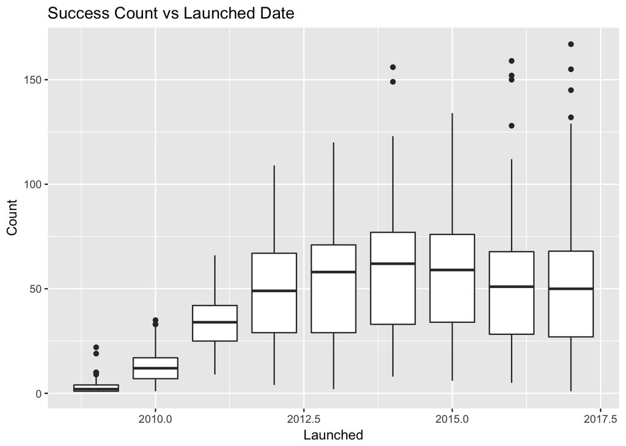

```r
ks_df%>%
  filter(state == "successful") %>%
  group_by(launch_date=factor(launched)) %>%
  summarise(count=n()) %>%
  ggplot(mapping = aes(x=year(launch_date),y=count)) +
  geom_boxplot(aes(group=year(launch_date))) +
  labs(title = "Success Count vs Launched Date",x = "Launched",y="Count")
```

First, let’s take a look at the proportion of successful cases. We can see only 40% of the projects in our data were successful.

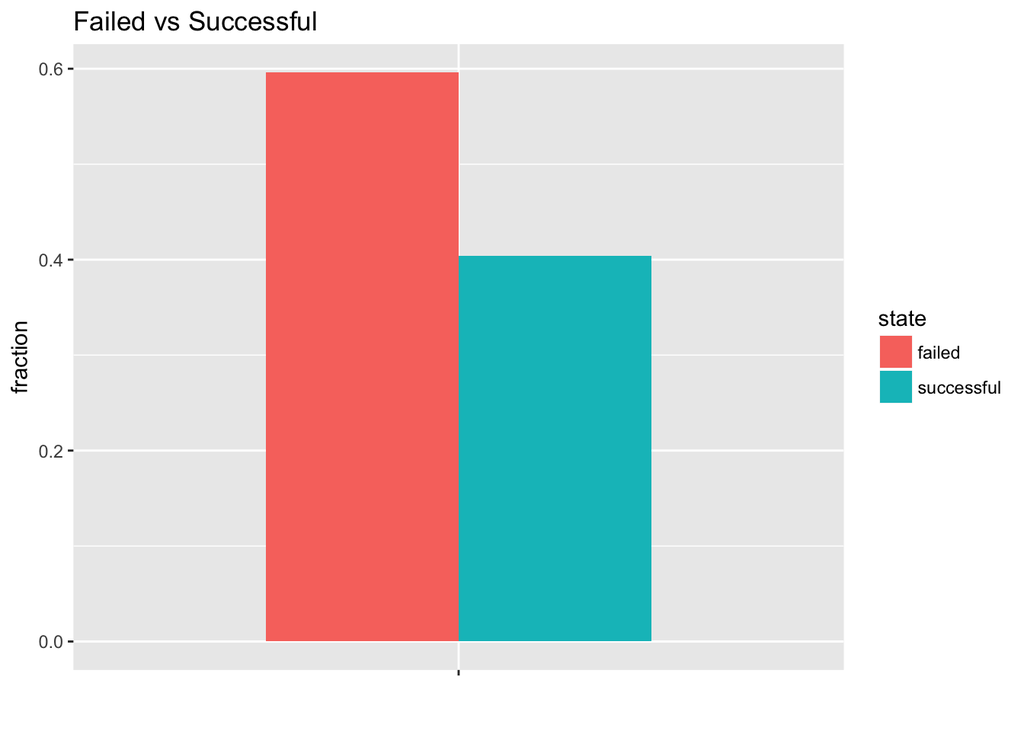

```r
ks_df %>%
  group_by(state) %>%
  summarise(count = n()) %>%
  mutate(frac=count/nrow(ks_df)) %>%
  ggplot(aes(x = "", y = frac, fill = state)) +
  geom_bar(width = 0.5, stat = "identity", position = "dodge") +
  labs(title = "Failed vs Successful",x = "",y="fraction")
```

Second, we will see the case number comparisons between successful and failed across different main categories. The differences are remarkable in both number and ratio across category.

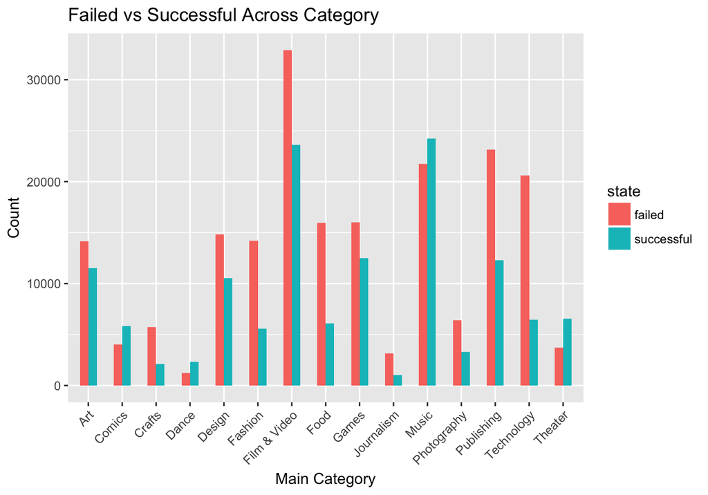

```r
ks_df %>%
  group_by(main_category,state) %>%
  summarise(cnt = n()) %>%
  ggplot(aes(x = main_category, y= cnt, fill = state)) +
geom_bar(stat="identity", width=.5, position = "dodge")  +
  theme(axis.text.x = element_text(angle = 45, hjust = 1)) +
  labs(title = "Failed vs Successful Across Category",x = "Main Category",y="Count")
```

We can also explore the relationship between state and goal by plotting a scatter plot. We can infer from the plot that average goal for failed projects are generally much higher that those of succeeded.

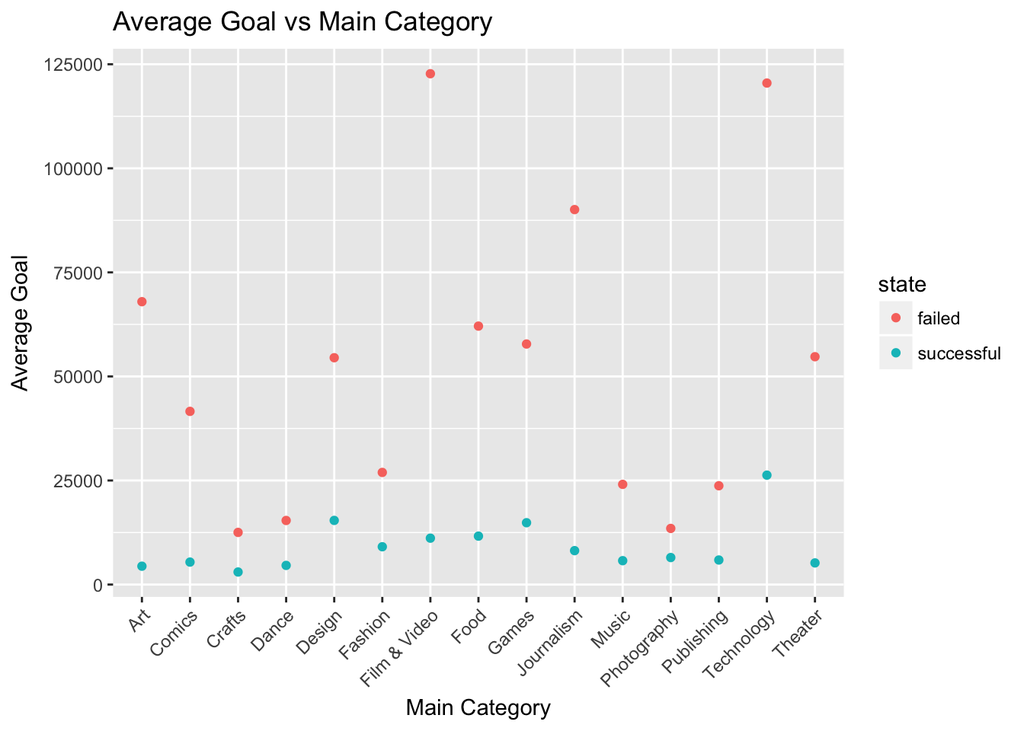

```r
ks_df%>%
  group_by(main_category, state) %>%
  summarise(mean_goal = mean(goal)) %>%
  ggplot(mapping = aes(x=main_category,y=mean_goal, color=state)) +
  geom_point() +
  theme(axis.text.x = element_text(angle = 45, hjust = 1)) +
  labs(title = "Average Goal vs Main Category",x = "Main Category",y="Average Goal")
```

Then you might ask if successful projects had lasted longer than the failed. Let’s draw a scatter plot to address the issue. The result is a little surprise but makes sense after some thinking: successful projects are usually popular thus fill up quickly while failed projects are difficult to get any attention so they need to wait longer.

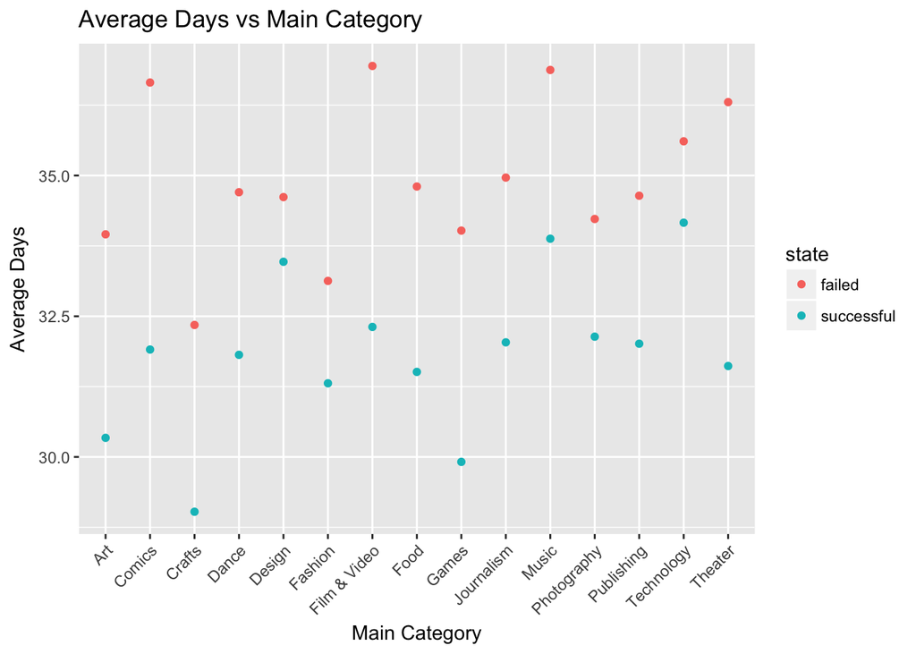

```r
ks_df%>%
  group_by(main_category, state)%>%
  summarise(mean_days=mean(days)) %>%
  ggplot(mapping = aes(x=main_category,y=mean_days, color=state)) +
  geom_point() +
  theme(axis.text.x = element_text(angle = 45, hjust = 1)) +
  labs(title = "Average Days vs Main Category",x = "Main Category",y="Average Days")
```

Next, we can see some statistics to explore the data from another perspective.

```r
ks_df%>%
  group_by(state) %>%
  summarise(mean_goal=mean(goal))
```

```
## # A tibble: 2 x 2
##   state      mean_goal
##   <chr>          <dbl>
## 1 failed         63175
## 2 successful      9533
```

It is very surprising that the average goal failed projects held is more than 6 times of successful cases’.

### 3. Machine Learning

Machine learning is all about finding patterns in data and being able to make predictions. Our data include a feature `state`, which can be seen as the label of the project. We’ll use a specific kind of learning algorithm called supervised machine learning because we have access to the true result (successful/failed) of each project in our dataset. In supervised machine, we’ll train some predictor using some portion of the data as our trainning data, and we’ll see how well this predictor predicts by testing it using the other portion of the data.

#### 3.1 Choosing Hypothesis

We have already decided to train our machine to predict if a project will be succeed or not given the features of it. The next step is choosing what our hypothesis is. Our data doesn’t seem to be linear or follow the form of a well-defined function, so we want to use a non linear model. We want to choose from Decision Tree and Random Forest. We’ll learn how to find the better.

#### 3.2 Training Algorithms

There are many ways to predict the success of a Kickstarter Project, and since predicting whether a project will be successful or not is binary, we will be using classification models for the prediction.

A decision tree is a flowchart-like structure in which each internal node represents a “test” on an attribute (e.g. whether a coin flip comes up heads or tails), each branch represents the outcome of the test, and each leaf node represents a class label (decision taken after computing all attributes). The paths from root to leaf represent classification rules.

Random forests are an ensemble learning method for classification, regression and other tasks, that operate by constructing a multitude of decision trees at training time and outputting the class that is the mode of the classes (classification) or mean prediction (regression) of the individual trees. For more information, look here: https://en.wikipedia.org/wiki/Random_forest.

#### 3.3 Splitting Data

Now we’re ready to split our data into test and training. We will not touch the test data until we have a model to test after splitting. When we split our data into test and train, we want as little difference in the distribution between these two datasets as possible. So we’ll shuffle our data before splitting.

```r
# Randomize the data
randomized_df <- sample_frac(ks_df, 1)
# Split the data
cutoff <- as.integer(nrow(randomized_df)/10)
ks_train <- slice(randomized_df, 0:cutoff)
ks_test <- slice(randomized_df, cutoff+1:n())
ks_test
```

```
## # A tibble: 298,508 x 14
##         ID name      main_category category currency launched   deadline
##      <int> <chr>     <chr>         <chr>    <chr>    <date>     <date>
##  1  1.36e⁹ MUSIC VI… Film & Video  Shorts   USD      2010-06-21 2010-07-29
##  2  5.93e⁸ "\"Genes… Theater       Theater  USD      2012-06-22 2012-07-22
##  3  1.21e⁹ DECCO th… Technology    Gadgets  CAD      2017-04-12 2017-05-27
##  4  1.02e⁹ Sexy Sui… Technology    Sound    AUD      2015-05-09 2015-06-08
##  5  1.89e⁹ TV Docum… Film & Video  Documen… GBP      2014-04-07 2014-05-07
##  6  7.26e⁸ Yolo, Wi… Design        Product… USD      2013-04-03 2013-05-03
##  7  8.23e⁸ Spooky T… Publishing    Art Boo… USD      2017-02-24 2017-03-26
##  8  1.04e⁸ Ferroflu… Design        Product… USD      2016-10-05 2016-11-09
##  9  6.18e⁸ Nancarro… Music         Classic… USD      2012-10-02 2012-11-05
## 10  3.47e⁸ Chocolat… Food          Food     USD      2014-07-19 2014-08-18
## # ... with 298,498 more rows, and 7 more variables: state <chr>,
## #   backers <int>, country <chr>, pledged <dbl>, goal <dbl>, days <int>,
## #   word_count <int>
```

We need to factor the non-numeric features to be able to train.

```r
ks_train <- ks_train %>%
  mutate(
  category = as.integer(factor(category)),
  main_category = as.integer(factor(main_category)),
  currency = as.integer(factor(currency)),
  country = as.integer(factor(country)),
  launched = as.numeric(launched),
  deadline = as.numeric(deadline),
  state = as.integer(factor(state))
  ) %>%
  select(-name)

ks_test <- ks_test %>%
  mutate(
  category = as.integer(factor(category)),
  main_category = as.integer(factor(main_category)),
  currency = as.integer(factor(currency)),
  country = as.integer(factor(country)),
  launched = as.numeric(launched),
  deadline = as.numeric(deadline),
  state = as.integer(factor(state))
  ) %>%
  select(-name)
```

### 4. Hypothesis Testing